# GLM_poisson

Wenxing Xu

2025-05-12

### 3.2.1. Generalised Linear Models (GLM) with Poisson Family

After first modeling with a linear model, we decided to conduct a further analysis on delivery speed. It is important to understand which variables significantly impact delivery speed: is it the weather conditions, traffic conditions, or even the type of vehicle? The variable `average_speed_kmph` is derived by dividing `distance_km` by `delivery_time_min`, and then converted to an integer. In this case, `average_speed_kmph` meets the requirement for a Poisson model, which assumes count data as the response variable.

#### 3.2.1.1 Modeling

Before starting the modeling, the `traffic_level_factor` variable is convert to an unordered factor, and its reference level is set to `Very Low`, so that all other traffic levels are compared against this baseline.

In the initial Poisson model, continuous variables such as `courier_age_years`, `temperature_celsius`, `humidity_percent`, `precipitation_mm`, and `distance_km`, as well as categorical variables like `traffic_level_factor`, `vehicle_type_factor`, and `weather_category`, are included in the Poisson model in the first round to examine the validity of these predictors. The goal is to evaluate the significance of these variables in explaining variations in average_speed_kmph. The results showed in the model summary indicates that the p-values for `courier_age_years`, `precipitation_mm`, and `vehicle_type_factor` are greater than 0.05, suggesting that they do not contribute significantly to the model. Therefore, they will not be considered in the second round of modeling.

```r
suppressPackageStartupMessages(library(tidyverse))
library(tidyverse)
# read data
df_clean <- read.csv("../data/cleaned_data.csv")


#  Convert to unordered factor
df_clean$traffic_level_factor <- factor(df_clean$traffic_level_factor, ordered = FALSE)
#  Set the reference level
df_clean$traffic_level_factor <- relevel(df_clean$traffic_level_factor, ref = "very low")

# regression with glm poisson model
poisson.model.test <- glm(
  average_speed_kmph ~ courier_age_years + temperature_celsius + humidity_percent + precipitation_mm +
    distance_km + traffic_level_factor + vehicle_type_factor +
    weather_category,
  data = df_clean,
  family = poisson(link="log")
)

# check model summary
summary(poisson.model.test)
```

```
##
## Call:
## glm(formula = average_speed_kmph ~ courier_age_years + temperature_celsius +
##     humidity_percent + precipitation_mm + distance_km + traffic_level_factor +
##     vehicle_type_factor + weather_category, family = poisson(link = "log"),
##     data = df_clean)
##
## Coefficients:
##                                       Estimate Std. Error z value Pr(>|z|)
## (Intercept)                          2.684e+00  7.414e-02  36.200  < 2e-16 ***
## courier_age_years                    3.911e-05  4.020e-04   0.097    0.923
## temperature_celsius                 -5.706e-03  7.528e-04  -7.579 3.47e-14 ***
## humidity_percent                    -1.529e-03  1.899e-04  -8.051 8.18e-16 ***
## precipitation_mm                     1.280e-01  1.203e-01   1.064    0.287
## distance_km                          3.618e-02  4.718e-04  76.692  < 2e-16 ***
## traffic_level_factorhigh             1.616e-01  1.429e-02  11.305  < 2e-16 ***
## traffic_level_factorlow              2.114e-01  1.319e-02  16.034  < 2e-16 ***
## traffic_level_factormoderate         2.748e-01  1.321e-02  20.799  < 2e-16 ***
## traffic_level_factorvery high       -1.434e-01  1.715e-02  -8.361  < 2e-16 ***
## vehicle_type_factorelectric_scooter -4.326e-02  6.888e-02  -0.628    0.530
## vehicle_type_factormotorcycle       -5.852e-02  6.846e-02  -0.855    0.393
## vehicle_type_factorscooter          -6.086e-02  6.851e-02  -0.888    0.374
## weather_categoryPoor Visibility     -4.591e-02  5.706e-03  -8.045 8.60e-16 ***
## weather_categoryRainy               -7.180e-02  8.426e-03  -8.520  < 2e-16 ***
## ---
## Signif. codes:  0 '***' 0.001 '**' 0.01 '*' 0.05 '.' 0.1 ' ' 1
##
## (Dispersion parameter for poisson family taken to be 1)
##
##     Null deviance: 21628.6  on 9034  degrees of freedom
## Residual deviance:  7492.1  on 9020  degrees of freedom
## AIC: 51224
##
## Number of Fisher Scoring iterations: 4
```

The second attempt of the Poisson model involves a reduced set of predictors: only `temperature_celsius`, `humidity_percent`, `distance_km`, `traffic_level_factor`, and `weather_category` are included. All remaining predictors show p-values far below 0.05, which indicates all the predictors contribute to the model.

Another important improvement lies in the ´AIC´ values: the reduced model yields a slightly lower ´AIC´, decreasing from 51224 to 51219, suggesting a better model fit with fewer variables. The Akaike Information Criterion (AIC) is a measure used to compare the quality of statistical models, particularly for models fitted to the same dataset. It helps identify the model that best balances goodness of fit and model simplicity (Wikipedia contributors (2025)).

Additionally, the ´residual deviance´ slightly increases from 7492.1 to 7497.7. While lower deviance generally indicates a better fit (closer to the saturated model), more parameters tend to reduce residual deviance. Therefore, a small increase does not automatically justify a more complex model (UCLA Statistical Consulting Group (n.d.); Statology (n.d.); Stack Exchange contributors (n.d.)).

Overall, the second Poisson model is more parsimonious and performs better based on the AIC value. The estimated model,expressed in its exponentiated form, is:

$$\begin{aligned}
\text{average_speed_kmph} = \exp(&\, 2.627
- 0.006 \cdot \text{temperature_celsius} \\
&- 0.002 \cdot \text{humidity_percent}
+ 0.036 \cdot \text{distance_km} \\
&+ 0.162 \cdot \text{traffic_level_factorhigh}
+ 0.212 \cdot \text{traffic_level_factorlow} \\
&+ 0.275 \cdot \text{traffic_level_factormoderate}
- 0.143 \cdot \text{traffic_level_factorvery high} \\
&- 0.046 \cdot \text{weather_categoryPoorVisibility}
- 0.072 \cdot \text{weather_categoryRainy})
\end{aligned}$$

```r
# check traffic_level_factor
table(df_clean$traffic_level_factor, useNA = "always")
```

```
##
##  very low      high       low  moderate very high      <NA>
##       632      2727      1717      2212      1747         0
```

```r
# Refine the Poisson regression by removing unnecessary variables.
# regression with glm poisson model
poisson.model <- glm(
  average_speed_kmph ~ temperature_celsius + humidity_percent + distance_km + traffic_level_factor +
    weather_category,
  data = df_clean,
  family = poisson(link="log")
)

# check model summary
summary(poisson.model)
```

```
##
## Call:
## glm(formula = average_speed_kmph ~ temperature_celsius + humidity_percent +
##     distance_km + traffic_level_factor + weather_category, family = poisson(link = "log"),
##     data = df_clean)
##
## Coefficients:
##                                   Estimate Std. Error z value Pr(>|z|)
## (Intercept)                      2.6265320  0.0258937 101.435  < 2e-16 ***
## temperature_celsius             -0.0056815  0.0007523  -7.552 4.30e-14 ***
## humidity_percent                -0.0015307  0.0001898  -8.063 7.44e-16 ***
## distance_km                      0.0361522  0.0004714  76.686  < 2e-16 ***
## traffic_level_factorhigh         0.1620592  0.0142886  11.342  < 2e-16 ***
## traffic_level_factorlow          0.2117392  0.0131838  16.061  < 2e-16 ***
## traffic_level_factormoderate     0.2751108  0.0132080  20.829  < 2e-16 ***
## traffic_level_factorvery high   -0.1425863  0.0171471  -8.315  < 2e-16 ***
## weather_categoryPoor Visibility -0.0458503  0.0057025  -8.040 8.95e-16 ***
## weather_categoryRainy           -0.0717777  0.0084220  -8.523  < 2e-16 ***
## ---
## Signif. codes:  0 '***' 0.001 '**' 0.01 '*' 0.05 '.' 0.1 ' ' 1
##
## (Dispersion parameter for poisson family taken to be 1)
##
##     Null deviance: 21628.6  on 9034  degrees of freedom
## Residual deviance:  7497.7  on 9025  degrees of freedom
## AIC: 51219
##
## Number of Fisher Scoring iterations: 4
```

```r
# print the regression formula with coefficients
cat("Log(average_speed_kmph) = ", paste0(
  round(coef(poisson.model)[1], 3), " + ",
  paste0(names(coef(poisson.model))[-1], " * ", round(coef(poisson.model)[-1], 3), collapse = " + ")
))
```

[output not shown]

#### 3.2.1.2 Interpretation of coefficients

Because the Poisson model uses a log-link function, the coefficients are first exponentiated.

- *Continous Variables*

The variable ´temperature_celsius´ has an exponentiated coefficient of 0.99, which means that for every 1°C increase in temperature, the expected delivery speed decreases by approximately 1%. This suggests that higher temperatures slightly reduce speed, possibly due to fatigue or decreased performance in hot weather.

The variable ´distance_km´ has an exponentiated coefficient of 1.04. This indicates that for every 1 km increase in distance, the expected delivery speed increases by 4%. Longer delivery distances are associated with slightly higher speeds, possibly because longer routes include faster segments like main roads or highways.

The variable humidity_percent has an exponentiated coefficient of 1.00, indicating no practical effect on delivery speed.

- *Categorical Variables*

The variable traffic_level_factor is an unordered factor with ´Very Low´ as the reference category. ´traffic_level_factorLow´ has an exponentiated coefficient of 1.24, suggesting increase 24% in speed compared to ´Very Low´. ´traffic_level_factorModerate´: 1.32, 32% increase ´traffic_level_factorHigh´: 1.18, 18% increase ´traffic_level_factorVery High´: 0.87, a 13% decrease in speed. These results indicate that mild to moderate traffic conditions are associated with faster delivery speeds, possibly because very low traffic occurs at off-peak hours or in low-demand areas. However, “Very High” traffic reduces speed significantly, as expected.

For the ´weather_category´, ´weather_categoryClear´ was taken as the baseline. ´weather_categoryPoor Visibility´ results exponentialed coefficient 0.96, indicating about 4% decrease in speed. ´weather_categoryRainy´ with exponentialed coefficient 0.93, suggesting 7% decrease comparing to the baseline. These results quantitatively describe how adverse weather conditions reduce delivery speed, with rain having a slightly greater negative effect than poor visibility.

```r
#++++++++++++++++++++++++++++++++++++++++++

names(coef(poisson.model))
```

```
##  [1] "(Intercept)"                     "temperature_celsius"
##  [3] "humidity_percent"                "distance_km"
##  [5] "traffic_level_factorhigh"        "traffic_level_factorlow"
##  [7] "traffic_level_factormoderate"    "traffic_level_factorvery high"
##  [9] "weather_categoryPoor Visibility" "weather_categoryRainy"
```

```r
#coefficients of the poisson Mode
# first on traffic_level_factor
coef(poisson.model)[c("traffic_level_factorhigh",
                      "traffic_level_factorlow",
                      "traffic_level_factormoderate",
                      "traffic_level_factorvery high")]
```

```
##      traffic_level_factorhigh       traffic_level_factorlow
##                     0.1620592                     0.2117392
##  traffic_level_factormoderate traffic_level_factorvery high
##                     0.2751108                    -0.1425863
```

```r
exp(coef(poisson.model)[c("traffic_level_factorhigh",
                          "traffic_level_factorlow",
                          "traffic_level_factormoderate",
                          "traffic_level_factorvery high")]) %>% round(digits = 2)
```

```
##      traffic_level_factorhigh       traffic_level_factorlow
##                          1.18                          1.24
##  traffic_level_factormoderate traffic_level_factorvery high
##                          1.32                          0.87
```

```r
# then on weather_category
coef(poisson.model)[c("weather_categoryPoor Visibility", "weather_categoryRainy")]
```

```
## weather_categoryPoor Visibility           weather_categoryRainy
##                     -0.04585035                     -0.07177766
```

```r
exp(coef(poisson.model)[c("weather_categoryPoor Visibility", "weather_categoryRainy")]) %>% round(digits = 2)
```

```
## weather_categoryPoor Visibility           weather_categoryRainy
##                            0.96                            0.93
```

```r
# check for continuous variables
coef(poisson.model)[c("temperature_celsius", "humidity_percent","distance_km")]
```

```
## temperature_celsius    humidity_percent         distance_km
##        -0.005681475        -0.001530663         0.036152239
```

```r
exp(coef(poisson.model)[c("temperature_celsius", "humidity_percent","distance_km")]) %>% round(digits = 2)
```

```
## temperature_celsius    humidity_percent         distance_km
##                0.99                1.00                1.04
```

#### 3.2.1.3 Comparison of Real vs. Simulated Delivery Speeds by Traffic Level

To assess the adequacy of the Poisson regression model, we simulate delivery speeds using the fitted model and compare them to the actual observed values. Specifically, predicted values of average_speed_kmph are generated via the simulate() function based on the fitted Poisson model. A combined dataset is then constructed that includes both the real and simulated values, with traffic_level_factor as the grouping variable.

Overall, the model captures the general trend in delivery speeds across traffic conditions:

Speeds increase from “Very Low” to “Moderate” traffic levels in both real and simulated data, aligning with the previously observed coefficients.

The Simulated values closely follow the center and spread of the Real data, especially under low to moderate traffic conditions.

This comparison validates that the Poisson model reasonably replicates key patterns in the data and supports its use for simulating delivery behavior under varying traffic levels.

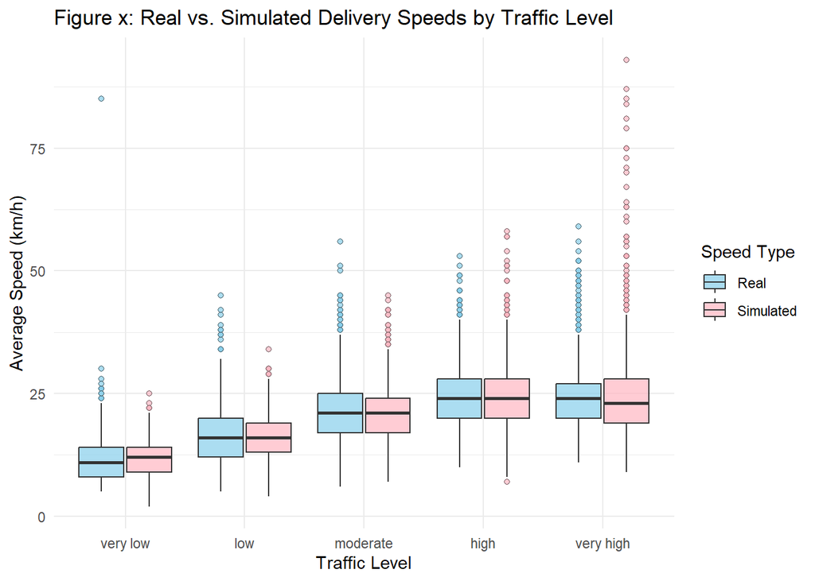

```r
# simulate some data from this model
library(ggplot2)
set.seed(2)
sim.data.average_speed_kmph.Poisson <- simulate(poisson.model)
names(sim.data.average_speed_kmph.Poisson) <- "sim_average_speed_kmph"

# Create combined data frame for plotting
df_plot_combined <- bind_rows(
  df_clean %>%
    select(Traffic_Level = traffic_level_factor, speed = average_speed_kmph) %>%
    mutate(Type = "Real"),

  data.frame(
    Traffic_Level = df_clean$traffic_level_factor,
    speed = sim.data.average_speed_kmph.Poisson$sim_average_speed_kmph,
    Type = "Simulated"
  )
)

# ensures the plot uses the correct order
df_plot_combined$Traffic_Level <- factor(
  df_plot_combined$Traffic_Level,
  levels = c("very low", "low", "moderate", "high", "very high"),
  ordered = TRUE
)

# Plot grouped boxplot
ggplot(df_plot_combined, aes(x = Traffic_Level, y = speed, fill = Type)) +
  geom_boxplot(outlier.shape = 21, alpha = 0.7, position = position_dodge(width = 0.8)) +
  scale_fill_manual(values = c("Real" = "skyblue", "Simulated" = "lightpink")) +
  labs(
    title = "Figure x: Real vs. Simulated Delivery Speeds by Traffic Level",
    x = "Traffic Level",
    y = "Average Speed (km/h)",
    fill = "Speed Type"
  ) +
  theme_minimal()
```

#### 3.2.1.4 Residual Analysis

To evaluate the adequacy of the Poisson regression model, we conducted a residual analysis using deviance, Pearson, and raw residuals.

**Overdispersion Check** To check for overdispersion, we calculated the overdispersion statistic using Pearson residuals. The resulting overdispersion ratio is 0.83. Since this value is less than 1, it suggests underdispersion — meaning the observed variance in the data is slightly lower than what the Poisson distribution assumes. This is not problematic and indicates that the model may be slightly conservative in its variance estimation but overall remains valid.

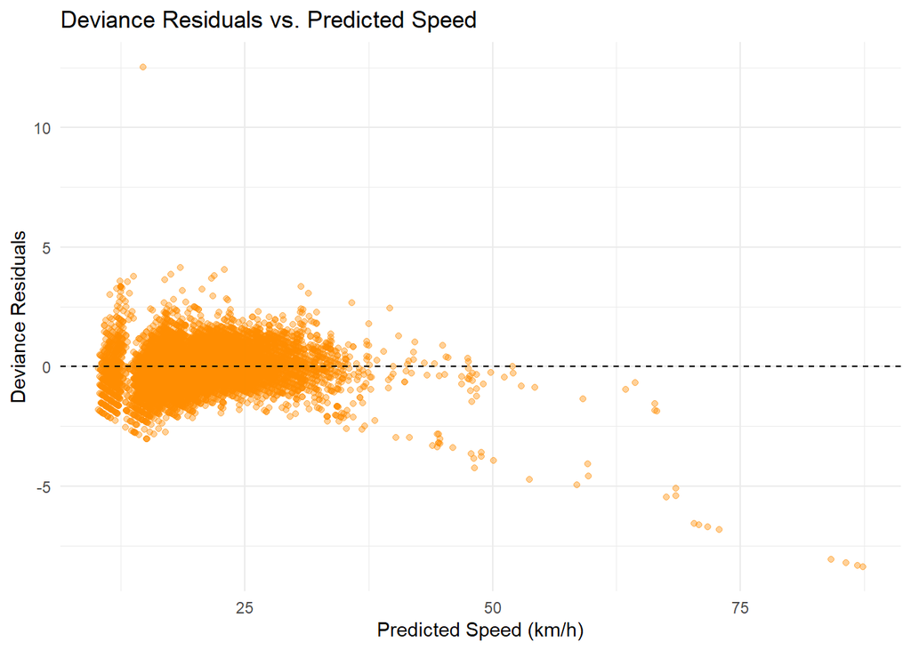

```r
# residual analysis
# 1.compute residuals
df_clean$residuals_raw <- residuals(poisson.model, type = "response")   # raw residuals
df_clean$residuals_deviance <- residuals(poisson.model, type = "deviance")  # deviance residuals
df_clean$residuals_pearson <- residuals(poisson.model, type = "pearson")  # for overdispersion check
df_clean$predicted_speed_kmph <- predict(poisson.model, type = "response") # Compute predicted values

# 2. Plot: Predicted vs. Residuals
ggplot(df_clean, aes(x = predicted_speed_kmph, y = residuals_deviance)) +
  geom_point(alpha = 0.4, color = "darkorange") +
  geom_hline(yintercept = 0, linetype = "dashed") +
  labs(
    title = "Deviance Residuals vs. Predicted Speed",
    x = "Predicted Speed (km/h)",
    y = "Deviance Residuals"
  ) +
  theme_minimal()
```

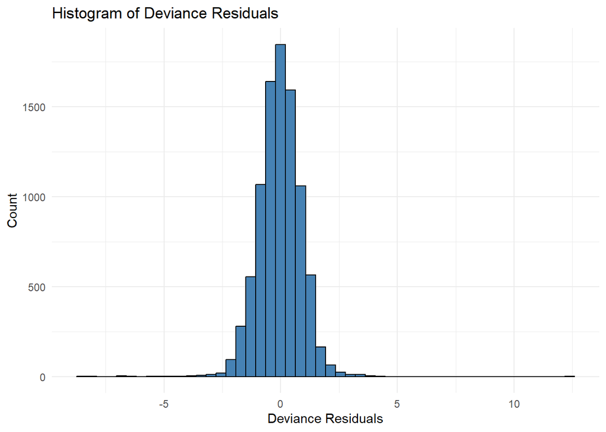

```r
# 3. Histogram of Residuals
ggplot(df_clean, aes(x = residuals_deviance)) +
  geom_histogram(bins = 50, fill = "steelblue", color = "black") +
  labs(
    title = "Histogram of Deviance Residuals",
    x = "Deviance Residuals",
    y = "Count"
  ) +
  theme_minimal()
```

```r
# 4. Check for Overdispersion
overdispersion <- sum(residuals(poisson.model, type = "pearson")^2) / poisson.model$df.residual
overdispersion  # > 1 suggests overdispersion; if >>1, Poisson may not be appropriate
```

```
## [1] 0.827608
```

Stack Exchange contributors. (n.d.). *When someone says residual deviance/df should 1 for a poisson model, how approximate is that?* https://stats.stackexchange.com/questions/37732/when-someone-says-residual-deviance-df-should-1-for-a-poisson-model-how-appro

Statology. (n.d.). *How to interpret null & residual deviance (with examples)*. https://www.statology.org/null-residual-deviance/

UCLA Statistical Consulting Group. (n.d.). *Poisson regression | r data analysis examples*. https://stats.oarc.ucla.edu/r/dae/poisson-regression/

Wikipedia contributors. (2025). *Akaike information criterion*. https://en.wikipedia.org/wiki/Akaike_information_criterion